# **secr** simulations Mb

Murray Efford

2024-06-14

# Behavioural variation in detection parameter $\lambda_0$ Mb

The simulations described here are part of a series documenting the effect of breaching assumptions of spatially explicit capture–recapture models.

Unmodelled behavioural variation is a potential problem that has not been examined to my knowledge.

## Problem description

The SECR null model assumes $\lambda_0$ and $\sigma$ are not affected by whether an individual has been caught (detected) before. We model a general learned response in $\lambda_0$ and one that is detector-specific, and examine the resulting estimates from a null model.

## Settings

Square grid of 64 binary multi-catch traps at spacing $c = 2\sigma$.

The same conditions used for simulation and fitting.

| Parameter | Value(s) |
| --- | --- |
| detectfn | ‘HHN’ |
| D | $12.5 \sigma^{-2}$ |
| lambda0 | 0.1 |
| sigma | c/2 |
| noccasions | 10 |
| buffer | $4\sigma$ |
| nx | 32 |

## Package version, date and platform

```r
source('../setup.R')
runsim  <- FALSE
figures <- TRUE
cache   <- TRUE
nrepl   <- 200
metadata(runsim) # if FALSE picks up saved metadata.RDS
```

```
## R version 4.3.2 (2023-10-31)
## Platform   x86_64-pc-linux-gnu (64-bit)
## Running    CentOS Linux 7 (Core)
## secr       4.6.7 2024-05-18
## secrdesign 2.9.2 2024-05-18
## Threads    40
## Run        Tue Jun 11 20:37:59 2024
```

## Simulation code

### Define Mb scenarios

```r
grid   <- make.grid(nx = 8, ny = 8, spacing = 40, detector = "multi")
detarg <- expand.arg(
    recapfactor = c(0.25,0.5,1,1.5,2),
    bk = c(FALSE,TRUE),
    sublist=list(detectpar = c('recapfactor','bk')))
fitarg <- list(detectfn = 'HHN', model = lambda0 ~ 1)
scen   <- make.scenarios(D = 12.5, noccasions = 10, detectfn = 14,
    lambda0 = 0.1, sigma = 20, detindex = 1:length(detarg), fitindex = 1)
```

```r
scenarioSummary(scen, grid)
```

```
##    scenario trapsindex noccasions nrepeats    D lambda0 sigma detectfn     En     Er     Em   En2
## 1         1          1         10        1 12.5     0.1    20       14 110.03 77.657 49.475 36.42
## 2         2          1         10        1 12.5     0.1    20       14 110.03 77.657 49.475 36.42
## 3         3          1         10        1 12.5     0.1    20       14 110.03 77.657 49.475 36.42
## 4         4          1         10        1 12.5     0.1    20       14 110.03 77.657 49.475 36.42
## 5         5          1         10        1 12.5     0.1    20       14 110.03 77.657 49.475 36.42
## 6         6          1         10        1 12.5     0.1    20       14 110.03 77.657 49.475 36.42
## 7         7          1         10        1 12.5     0.1    20       14 110.03 77.657 49.475 36.42
## 8         8          1         10        1 12.5     0.1    20       14 110.03 77.657 49.475 36.42
## 9         9          1         10        1 12.5     0.1    20       14 110.03 77.657 49.475 36.42
## 10       10          1         10        1 12.5     0.1    20       14 110.03 77.657 49.475 36.42
##       esa CF rotRSE rotRSEB arrayN arrayspace arrayspan saturation detperHR.median       k
## 1  8.8021  1 0.1135  0.0929     64          2    19.799    0.25945               4 0.70711
## 2  8.8021  1 0.1135  0.0929     64          2    19.799    0.25945               4 0.70711
## 3  8.8021  1 0.1135  0.0929     64          2    19.799    0.25945               4 0.70711
## 4  8.8021  1 0.1135  0.0929     64          2    19.799    0.25945               4 0.70711
## 5  8.8021  1 0.1135  0.0929     64          2    19.799    0.25945               4 0.70711
## 6  8.8021  1 0.1135  0.0929     64          2    19.799    0.25945               4 0.70711
## 7  8.8021  1 0.1135  0.0929     64          2    19.799    0.25945               4 0.70711
## 8  8.8021  1 0.1135  0.0929     64          2    19.799    0.25945               4 0.70711
## 9  8.8021  1 0.1135  0.0929     64          2    19.799    0.25945               4 0.70711
## 10 8.8021  1 0.1135  0.0929     64          2    19.799    0.25945               4 0.70711
```

### Run Mb simulations

```r
Mbsims <- run.scenarios(
    nrepl     =  nrepl,
    scenarios = scen,
    trapset   = grid,
    det.args  = detarg,
    fit       = TRUE,
    fit.args  = fitarg,
    seed      = 12345)
saveRDS(Mbsims, file = 'Mbsims.RDS')
```

## Results

```
## Raw counts
##    recapfactor bk    n     r     nmov  dpa   rse    rpsv
## 1  0.25        FALSE 109.8 20.21 13    1.115 0.228  18.87
## 2  0.5         FALSE 110.5 40.55 25.97 1.22  0.1593 18.75
## 3  1           FALSE 109.3 76.89 48.87 1.399 0.1152 18.89
## 4  1.5         FALSE 108.8 110.7 70.14 1.55  0.0979 18.83
## 5  2           FALSE 110.1 145.2 92.16 1.685 0.0957 18.88
## 6  0.25        TRUE  110.2 53.2  45.8  1.403 0.1386 22.03
## 7  0.5         TRUE  110.1 61.57 47.44 1.404 0.1287 20.87
## 8  1           TRUE  109.4 76.95 48.76 1.398 0.115  18.72
## 9  1.5         TRUE  109.9 92.81 51.19 1.395 0.1048 17.51
## 10 2           TRUE  108.6 104.8 51.53 1.391 0.0997 16.56
## Density
##    recapfactor    bk true.D nvalid   EST  seEST      RB   seRB    RSE   RMSE  rRMSE   COV
## 1         0.25 FALSE   12.5    200 30.19 0.4615  1.4156 0.0369 0.2114 18.855 1.5084 0.000
```

[output cut: 33 more lines]

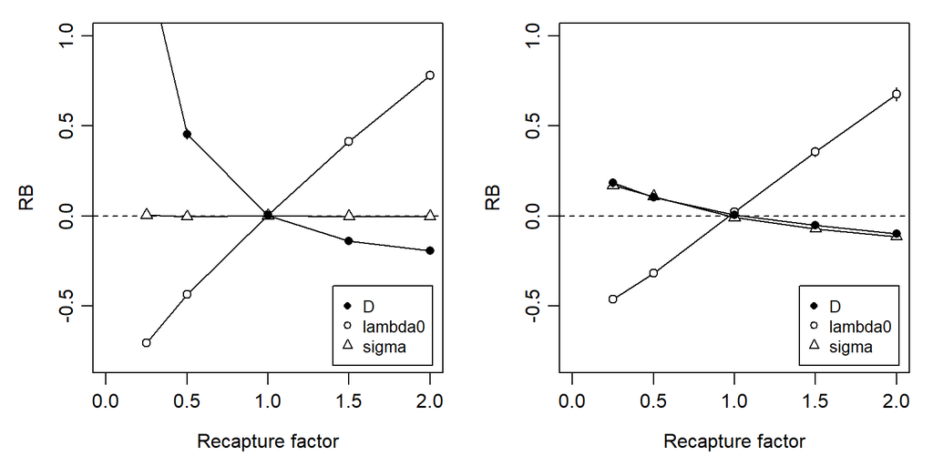

Relative bias of parameter estimates from null model given behavioural variation in lambda0

## Interpretation

Estimates of density from the null model are not robust to unmodelled behavioural variation in $\lambda_0$. Bias in the density estimates is much reduced when the learned response is specific to the trap site (bk), but then estimates of $\sigma$ also come to be biased. These results apply to traps and not to proximity detectors for which the behavioural response is poorly defined.

## One-off

Run this code to obtain results for a single scenario (here recapfactor = 2). Here we fit both a null model (lambda0~1) and the generating model (lambda0~b).

```r
source('../setup.R')
grid <- make.grid(nx = 8, ny = 8, spacing = 40, detector = "multi")
detarg <- list(detectpar = list(recapfactor = 2))
fitarg <- list(
    list(detectfn = 'HHN', model = lambda0~1),
    list(detectfn = 'HHN', model = lambda0~b)
)
scen <- make.scenarios(D = 12.5, noccasions = 10, detectfn = 14, lambda0 = 0.1,
                       sigma = 20, fitindex = 1:2)
oneoff <- run.scenarios(nrepl = 100, scen, trapset = grid, det.args = detarg,
    fit = TRUE, fit.args = fitarg, seed = 12345)
round(estimateSummary(oneoff, 'D'),4)
round(estimateSummary(oneoff, 'lambda0'),4)
```